# Incidence-Guided Treatment Assignment Designs for Spatial Cluster Randomized Trials

```
$`Design 5`
```

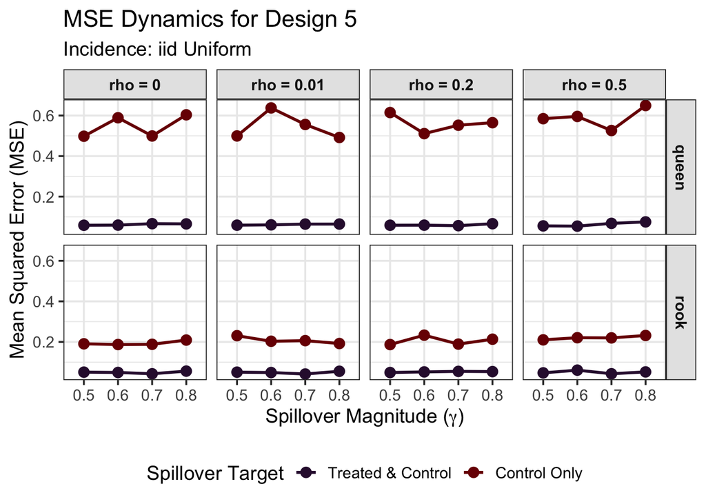

Per-design MSE line plots across gamma levels, for iid Uniform incidence (tau = 1.0).

```
$`Design 6`
```

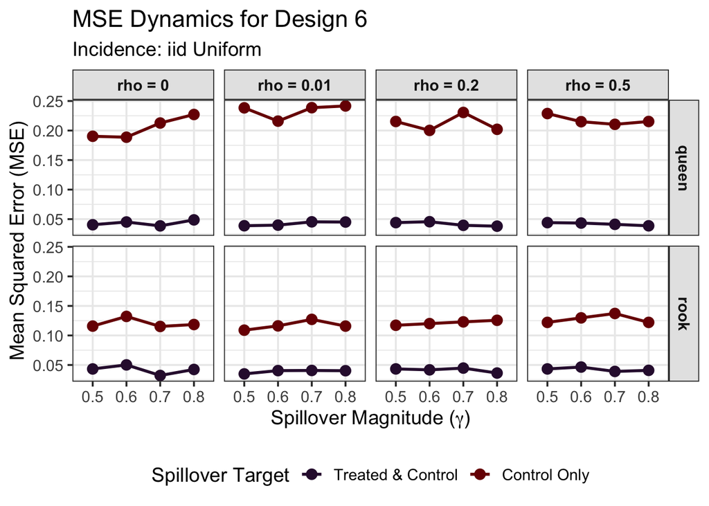

Per-design MSE line plots across gamma levels, for iid Uniform incidence (tau = 1.0).

```
$`Design 7`
```

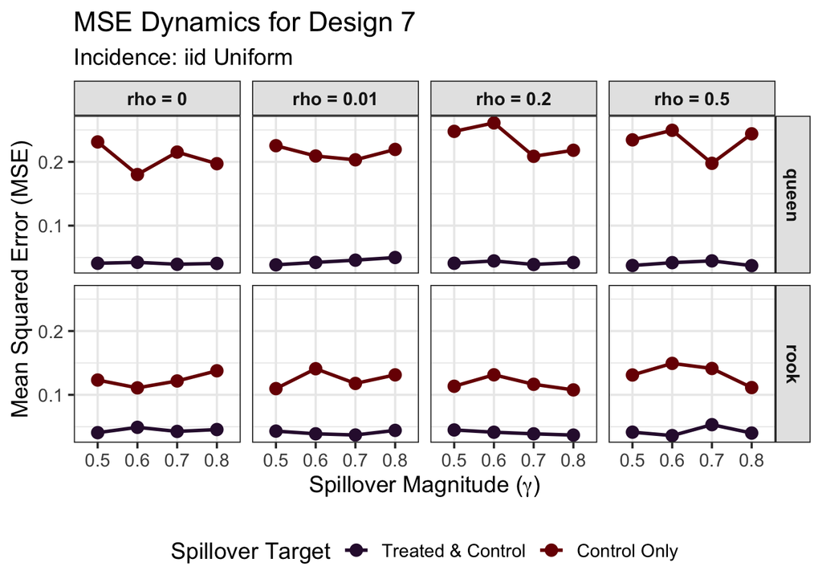

Per-design MSE line plots across gamma levels, for iid Uniform incidence (tau = 1.0).

```
$`Design 8`
```

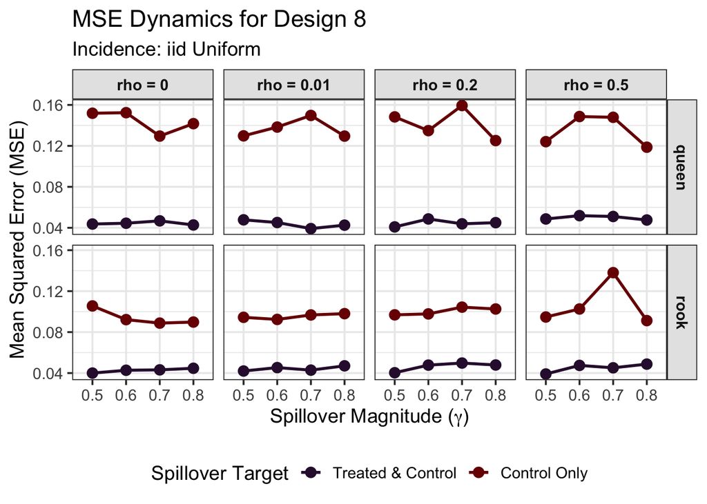

Per-design MSE line plots across gamma levels, for iid Uniform incidence (tau = 1.0).

## 12.5 Marginal Ranking Tables

### 12.5.1 iid Uniform

iid Uniform | Marginal rankings by Rho (outcome spatial autocorrelation) (tau = 1.0, rook and queen pooled).

| Design | Rho=0 | Rho=0.01 | Rho=0.2 | Rho=0.5 |
| --- | --- | --- | --- | --- |
| D3: Sat. Quadrants | 0.0801 (#1) | 0.0790 (#1) | 0.0827 (#1) | 0.0857 (#2) |
| D8: Inc.-Guided Sat. Q. | 0.0813 (#2) | 0.0801 (#2) | 0.0833 (#2) | 0.0841 (#1) |
| D6: Balanced Quartiles | 0.1026 (#3) | 0.1080 (#4) | 0.1042 (#3) | 0.1074 (#3) |
| D7: Balanced Halves | 0.1037 (#4) | 0.1061 (#3) | 0.1084 (#4) | 0.1119 (#4) |
| D4: Isolation Buffer | 0.1446 (#5) | 0.1399 (#5) | 0.1478 (#5) | 0.1497 (#5) |
| D5: 2x2 Blocking | 0.2133 (#6) | 0.2163 (#6) | 0.2197 (#6) | 0.2309 (#7) |
| D2: High Inc. Focus | 0.2249 (#7) | 0.2225 (#7) | 0.2290 (#7) | 0.2239 (#6) |
| D1: Checkerboard | 0.8130 (#8) | 0.7638 (#8) | 0.8076 (#8) | 0.7594 (#8) |

iid Uniform | Marginal rankings by Gamma (spillover magnitude) (tau = 1.0, rook and queen pooled).

| Design | Gamma=0.5 | Gamma=0.6 | Gamma=0.7 | Gamma=0.8 |
| --- | --- | --- | --- | --- |
| D3: Sat. Quadrants | 0.0827 (#2) | 0.0813 (#1) | 0.0814 (#1) | 0.0820 (#2) |
| D8: Inc.-Guided Sat. Q. | 0.0805 (#1) | 0.0833 (#2) | 0.0860 (#2) | 0.0789 (#1) |
| D6: Balanced Quartiles | 0.1043 (#3) | 0.1044 (#3) | 0.1073 (#4) | 0.1062 (#3) |
| D7: Balanced Halves | 0.1090 (#4) | 0.1106 (#4) | 0.1039 (#3) | 0.1065 (#4) |
| D4: Isolation Buffer | 0.1436 (#5) | 0.1461 (#5) | 0.1474 (#5) | 0.1448 (#5) |
| D5: 2x2 Blocking | 0.2153 (#6) | 0.2263 (#6) | 0.2109 (#6) | 0.2277 (#7) |
| D2: High Inc. Focus | 0.2217 (#7) | 0.2384 (#7) | 0.2241 (#7) | 0.2161 (#6) |
| D1: Checkerboard | 0.6944 (#8) | 0.7294 (#8) | 0.7758 (#8) | 0.9442 (#8) |

iid Uniform | Marginal rankings by Spillover Type (tau = 1.0, rook and queen pooled).

| Design | Spillover_Type=both | Spillover_Type=control_only |
| --- | --- | --- |
| D3: Sat. Quadrants | 0.0447 (#3) | 0.1190 (#1) |
| D8: Inc.-Guided Sat. Q. | 0.0451 (#4) | 0.1193 (#2) |
| D6: Balanced Quartiles | 0.0418 (#1) | 0.1693 (#4) |
| D7: Balanced Halves | 0.0420 (#2) | 0.1730 (#5) |
| D4: Isolation Buffer | 0.1448 (#6) | 0.1462 (#3) |
| D5: 2x2 Blocking | 0.0562 (#5) | 0.3838 (#7) |
| D2: High Inc. Focus | 0.1647 (#7) | 0.2855 (#6) |
| D1: Checkerboard | 0.2696 (#8) | 1.3023 (#8) |

### 12.5.2 Poisson (rho_X = 0.20)

Poisson (rho X = 0.20) | Marginal rankings by Rho (outcome spatial autocorrelation) (tau = 1.0, rook and queen pooled).

| Design | Rho=0 | Rho=0.01 | Rho=0.2 | Rho=0.5 |
| --- | --- | --- | --- | --- |
| D3: Sat. Quadrants | 0.0755 (#1) | 0.0760 (#1) | 0.0764 (#1) | 0.0824 (#1) |
| D8: Inc.-Guided Sat. Q. | 0.0780 (#2) | 0.0761 (#2) | 0.0860 (#2) | 0.0856 (#2) |
| D6: Balanced Quartiles | 0.1041 (#3) | 0.1030 (#3) | 0.1098 (#4) | 0.1090 (#3) |
| D7: Balanced Halves | 0.1125 (#4) | 0.1035 (#4) | 0.1028 (#3) | 0.1122 (#4) |
| D4: Isolation Buffer | 0.1477 (#5) | 0.1506 (#5) | 0.1459 (#5) | 0.1522 (#5) |
| D2: High Inc. Focus | 0.2155 (#6) | 0.2105 (#6) | 0.2162 (#6) | 0.2266 (#6) |
| D5: 2x2 Blocking | 0.2284 (#7) | 0.2266 (#7) | 0.2248 (#7) | 0.2323 (#7) |
| D1: Checkerboard | 0.7953 (#8) | 0.7938 (#8) | 0.7858 (#8) | 0.8103 (#8) |

Poisson (rho X = 0.20) | Marginal rankings by Gamma (spillover magnitude) (tau = 1.0, rook and queen pooled).

| Design | Gamma=0.5 | Gamma=0.6 | Gamma=0.7 | Gamma=0.8 |
| --- | --- | --- | --- | --- |
| D3: Sat. Quadrants | 0.0777 (#1) | 0.0757 (#1) | 0.0801 (#1) | 0.0767 (#1) |
| D8: Inc.-Guided Sat. Q. | 0.0802 (#2) | 0.0828 (#2) | 0.0814 (#2) | 0.0812 (#2) |
| D6: Balanced Quartiles | 0.1078 (#3) | 0.1034 (#3) | 0.1059 (#3) | 0.1088 (#3) |
| D7: Balanced Halves | 0.1083 (#4) | 0.1064 (#4) | 0.1070 (#4) | 0.1093 (#4) |
| D4: Isolation Buffer | 0.1498 (#5) | 0.1484 (#5) | 0.1467 (#5) | 0.1515 (#5) |
| D2: High Inc. Focus | 0.2184 (#6) | 0.2166 (#6) | 0.2232 (#6) | 0.2106 (#6) |
| D5: 2x2 Blocking | 0.2246 (#7) | 0.2250 (#7) | 0.2377 (#7) | 0.2247 (#7) |
| D1: Checkerboard | 0.7417 (#8) | 0.7508 (#8) | 0.8159 (#8) | 0.8768 (#8) |

Poisson (rho X = 0.20) | Marginal rankings by Spillover Type (tau = 1.0, rook and queen pooled).

| Design | Spillover_Type=both | Spillover_Type=control_only |
| --- | --- | --- |
| D3: Sat. Quadrants | 0.0433 (#3) | 0.1119 (#1) |
| D8: Inc.-Guided Sat. Q. | 0.0459 (#4) | 0.1169 (#2) |
| D6: Balanced Quartiles | 0.0421 (#1) | 0.1709 (#4) |
| D7: Balanced Halves | 0.0429 (#2) | 0.1726 (#5) |
| D4: Isolation Buffer | 0.1484 (#6) | 0.1497 (#3) |
| D2: High Inc. Focus | 0.1602 (#7) | 0.2742 (#6) |
| D5: 2x2 Blocking | 0.0555 (#5) | 0.4005 (#7) |
| D1: Checkerboard | 0.2694 (#8) | 1.3232 (#8) |

### 12.5.3 Poisson (rho_X = 0.50)

Poisson (rho X = 0.50) | Marginal rankings by Rho (outcome spatial autocorrelation) (tau = 1.0, rook and queen pooled).

| Design | Rho=0 | Rho=0.01 | Rho=0.2 | Rho=0.5 |
| --- | --- | --- | --- | --- |
| D3: Sat. Quadrants | 0.0746 (#1) | 0.0799 (#2) | 0.0822 (#2) | 0.0848 (#2) |
| D8: Inc.-Guided Sat. Q. | 0.0786 (#2) | 0.0772 (#1) | 0.0820 (#1) | 0.0845 (#1) |
| D7: Balanced Halves | 0.1040 (#3) | 0.1053 (#3) | 0.1074 (#3) | 0.1097 (#4) |
| D6: Balanced Quartiles | 0.1101 (#4) | 0.1061 (#4) | 0.1160 (#4) | 0.1082 (#3) |
| D4: Isolation Buffer | 0.1469 (#5) | 0.1503 (#5) | 0.1462 (#5) | 0.1466 (#5) |
| D2: High Inc. Focus | 0.2202 (#6) | 0.2247 (#6) | 0.2193 (#6) | 0.2334 (#7) |
| D5: 2x2 Blocking | 0.2255 (#7) | 0.2271 (#7) | 0.2211 (#7) | 0.2240 (#6) |
| D1: Checkerboard | 0.7828 (#8) | 0.7630 (#8) | 0.7681 (#8) | 0.8052 (#8) |

Poisson (rho X = 0.50) | Marginal rankings by Gamma (spillover magnitude) (tau = 1.0, rook and queen pooled).

| Design | Gamma=0.5 | Gamma=0.6 | Gamma=0.7 | Gamma=0.8 |
| --- | --- | --- | --- | --- |
| D3: Sat. Quadrants | 0.0780 (#1) | 0.0773 (#1) | 0.0859 (#2) | 0.0803 (#1) |
| D8: Inc.-Guided Sat. Q. | 0.0800 (#2) | 0.0782 (#2) | 0.0819 (#1) | 0.0823 (#2) |
| D7: Balanced Halves | 0.1108 (#3) | 0.1072 (#3) | 0.1049 (#3) | 0.1035 (#3) |
| D6: Balanced Quartiles | 0.1118 (#4) | 0.1093 (#4) | 0.1085 (#4) | 0.1108 (#4) |
| D4: Isolation Buffer | 0.1435 (#5) | 0.1506 (#5) | 0.1508 (#5) | 0.1452 (#5) |
| D2: High Inc. Focus | 0.2208 (#6) | 0.2214 (#6) | 0.2297 (#6) | 0.2256 (#7) |
| D5: 2x2 Blocking | 0.2210 (#7) | 0.2263 (#7) | 0.2300 (#7) | 0.2204 (#6) |
| D1: Checkerboard | 0.6930 (#8) | 0.7382 (#8) | 0.8349 (#8) | 0.8529 (#8) |

Poisson (rho X = 0.50) | Marginal rankings by Spillover Type (tau = 1.0, rook and queen pooled).

| Design | Spillover_Type=both | Spillover_Type=control_only |
| --- | --- | --- |
| D3: Sat. Quadrants | 0.0452 (#3) | 0.1155 (#2) |
| D8: Inc.-Guided Sat. Q. | 0.0463 (#4) | 0.1149 (#1) |
| D7: Balanced Halves | 0.0417 (#1) | 0.1715 (#4) |
| D6: Balanced Quartiles | 0.0430 (#2) | 0.1772 (#5) |
| D4: Isolation Buffer | 0.1508 (#6) | 0.1442 (#3) |
| D2: High Inc. Focus | 0.1664 (#7) | 0.2824 (#6) |
| D5: 2x2 Blocking | 0.0575 (#5) | 0.3913 (#7) |
| D1: Checkerboard | 0.2712 (#8) | 1.2883 (#8) |

### 12.5.4 Spatial (rho_X = 0.20)

Spatial (rho X = 0.20) | Marginal rankings by Rho (outcome spatial autocorrelation) (tau = 1.0, rook and queen pooled).

| Design | Rho=0 | Rho=0.01 | Rho=0.2 | Rho=0.5 |
| --- | --- | --- | --- | --- |
| D8: Inc.-Guided Sat. Q. | 0.0791 (#1) | 0.0773 (#2) | 0.0816 (#2) | 0.0798 (#1) |
| D3: Sat. Quadrants | 0.0798 (#2) | 0.0754 (#1) | 0.0800 (#1) | 0.0849 (#2) |
| D6: Balanced Quartiles | 0.1083 (#4) | 0.1040 (#3) | 0.1081 (#3) | 0.1081 (#3) |
| D7: Balanced Halves | 0.1037 (#3) | 0.1062 (#4) | 0.1126 (#4) | 0.1115 (#4) |
| D4: Isolation Buffer | 0.1451 (#5) | 0.1398 (#5) | 0.1412 (#5) | 0.1536 (#5) |
| D5: 2x2 Blocking | 0.2153 (#6) | 0.2285 (#6) | 0.2150 (#6) | 0.2217 (#6) |
| D2: High Inc. Focus | 0.2415 (#7) | 0.2424 (#7) | 0.2379 (#7) | 0.2376 (#7) |
| D1: Checkerboard | 0.7721 (#8) | 0.8015 (#8) | 0.7681 (#8) | 0.7578 (#8) |

Spatial (rho X = 0.20) | Marginal rankings by Gamma (spillover magnitude) (tau = 1.0, rook and queen pooled).

| Design | Gamma=0.5 | Gamma=0.6 | Gamma=0.7 | Gamma=0.8 |
| --- | --- | --- | --- | --- |
| D8: Inc.-Guided Sat. Q. | 0.0792 (#2) | 0.0781 (#1) | 0.0834 (#2) | 0.0772 (#1) |
| D3: Sat. Quadrants | 0.0782 (#1) | 0.0820 (#2) | 0.0798 (#1) | 0.0801 (#2) |
| D6: Balanced Quartiles | 0.1044 (#3) | 0.1081 (#3) | 0.1091 (#3) | 0.1070 (#3) |
| D7: Balanced Halves | 0.1073 (#4) | 0.1089 (#4) | 0.1093 (#4) | 0.1086 (#4) |
| D4: Isolation Buffer | 0.1489 (#5) | 0.1494 (#5) | 0.1430 (#5) | 0.1385 (#5) |
| D5: 2x2 Blocking | 0.2207 (#6) | 0.2087 (#6) | 0.2221 (#6) | 0.2290 (#6) |
| D2: High Inc. Focus | 0.2409 (#7) | 0.2463 (#7) | 0.2309 (#7) | 0.2412 (#7) |
| D1: Checkerboard | 0.6726 (#8) | 0.7076 (#8) | 0.8169 (#8) | 0.9024 (#8) |

Spatial (rho X = 0.20) | Marginal rankings by Spillover Type (tau = 1.0, rook and queen pooled).

| Design | Spillover_Type=both | Spillover_Type=control_only |
| --- | --- | --- |
| D8: Inc.-Guided Sat. Q. | 0.0451 (#4) | 0.1138 (#1) |
| D3: Sat. Quadrants | 0.0445 (#3) | 0.1155 (#2) |
| D6: Balanced Quartiles | 0.0421 (#1) | 0.1722 (#4) |
| D7: Balanced Halves | 0.0430 (#2) | 0.1740 (#5) |
| D4: Isolation Buffer | 0.1429 (#6) | 0.1470 (#3) |
| D5: 2x2 Blocking | 0.0571 (#5) | 0.3832 (#7) |
| D2: High Inc. Focus | 0.1673 (#7) | 0.3124 (#6) |
| D1: Checkerboard | 0.2712 (#8) | 1.2786 (#8) |

### 12.5.5 Spatial (rho_X = 0.50)

Spatial (rho X = 0.50) | Marginal rankings by Rho (outcome spatial autocorrelation) (tau = 1.0, rook and queen pooled).

| Design | Rho=0 | Rho=0.01 | Rho=0.2 | Rho=0.5 |
| --- | --- | --- | --- | --- |
| D8: Inc.-Guided Sat. Q. | 0.0775 (#1) | 0.0789 (#1) | 0.0821 (#2) | 0.0900 (#2) |
| D3: Sat. Quadrants | 0.0804 (#2) | 0.0816 (#2) | 0.0803 (#1) | 0.0865 (#1) |
| D7: Balanced Halves | 0.1035 (#4) | 0.1013 (#3) | 0.1052 (#3) | 0.1098 (#3) |
| D6: Balanced Quartiles | 0.1027 (#3) | 0.1069 (#4) | 0.1053 (#4) | 0.1134 (#4) |
| D4: Isolation Buffer | 0.1435 (#5) | 0.1433 (#5) | 0.1450 (#5) | 0.1507 (#5) |
| D2: High Inc. Focus | 0.2173 (#6) | 0.2215 (#6) | 0.2262 (#7) | 0.2258 (#7) |
| D5: 2x2 Blocking | 0.2227 (#7) | 0.2302 (#7) | 0.2251 (#6) | 0.2253 (#6) |
| D1: Checkerboard | 0.7757 (#8) | 0.7660 (#8) | 0.7795 (#8) | 0.7994 (#8) |

Spatial (rho X = 0.50) | Marginal rankings by Gamma (spillover magnitude) (tau = 1.0, rook and queen pooled).

| Design | Gamma=0.5 | Gamma=0.6 | Gamma=0.7 | Gamma=0.8 |
| --- | --- | --- | --- | --- |
| D8: Inc.-Guided Sat. Q. | 0.0827 (#1) | 0.0805 (#2) | 0.0824 (#1) | 0.0829 (#2) |
| D3: Sat. Quadrants | 0.0854 (#2) | 0.0783 (#1) | 0.0829 (#2) | 0.0822 (#1) |
| D7: Balanced Halves | 0.1063 (#3) | 0.1058 (#3) | 0.1049 (#3) | 0.1028 (#4) |
| D6: Balanced Quartiles | 0.1106 (#4) | 0.1082 (#4) | 0.1072 (#4) | 0.1023 (#3) |
| D4: Isolation Buffer | 0.1408 (#5) | 0.1447 (#5) | 0.1472 (#5) | 0.1499 (#5) |
| D2: High Inc. Focus | 0.2265 (#7) | 0.2222 (#7) | 0.2245 (#6) | 0.2176 (#6) |
| D5: 2x2 Blocking | 0.2203 (#6) | 0.2218 (#6) | 0.2364 (#7) | 0.2249 (#7) |
| D1: Checkerboard | 0.7065 (#8) | 0.7120 (#8) | 0.8151 (#8) | 0.8869 (#8) |

Spatial (rho X = 0.50) | Marginal rankings by Spillover Type (tau = 1.0, rook and queen pooled).

| Design | Spillover_Type=both | Spillover_Type=control_only |
| --- | --- | --- |
| D8: Inc.-Guided Sat. Q. | 0.0451 (#4) | 0.1192 (#1) |
| D3: Sat. Quadrants | 0.0440 (#3) | 0.1204 (#2) |
| D7: Balanced Halves | 0.0418 (#2) | 0.1681 (#4) |
| D6: Balanced Quartiles | 0.0415 (#1) | 0.1726 (#5) |
| D4: Isolation Buffer | 0.1437 (#6) | 0.1476 (#3) |
| D2: High Inc. Focus | 0.1550 (#7) | 0.2904 (#6) |
| D5: 2x2 Blocking | 0.0558 (#5) | 0.3959 (#7) |
| D1: Checkerboard | 0.2659 (#8) | 1.2943 (#8) |

# 13 Results: Best Design by Parameter Combination (Q3)

## 13.1 Rho x Gamma Best-Design Maps

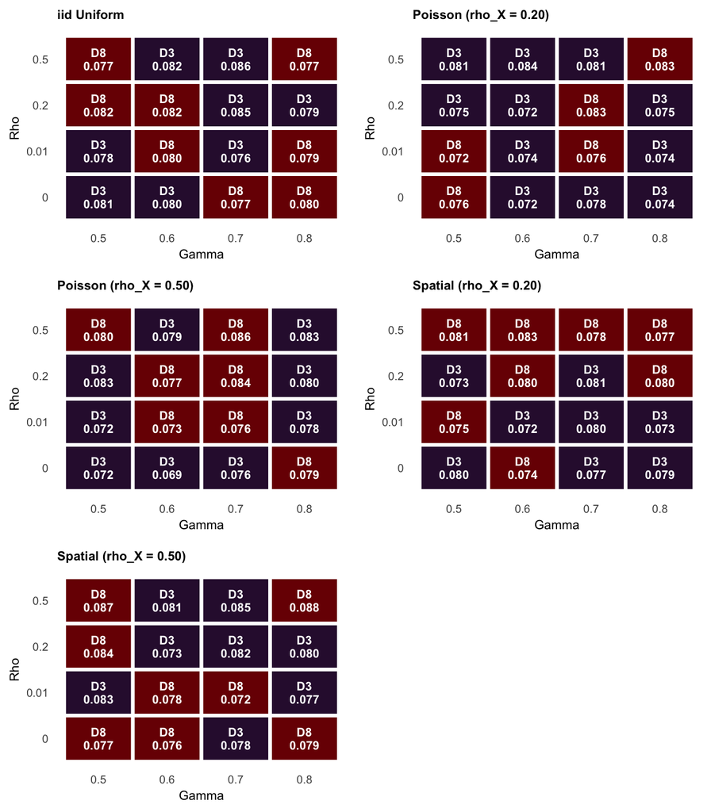

Best design heatmap: Rho vs. Gamma for each incidence config (tau = 1.0, rook and queen pooled). Each tile shows which design achieves the lowest average MSE.

## 13.2 Rho x Spillover Type Best-Design Maps

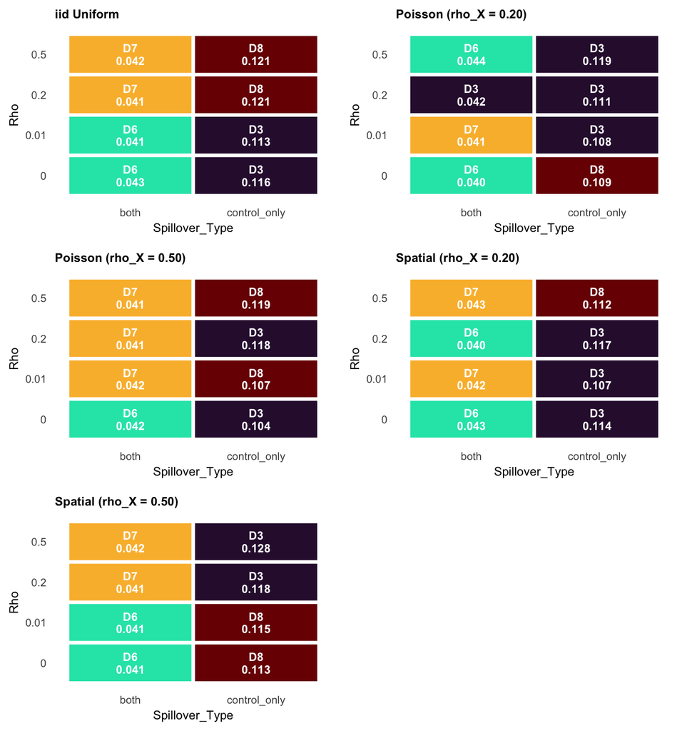

Best design heatmap: Rho vs. Spillover Type for each incidence config (tau = 1.0, rook and queen pooled). Reveals the key spillover-type interaction.

# 14 Per-Config Narrative Findings

The findings below are generated from the $\tau = 1.0$ results with rook and queen pooled. In every configuration the top two designs are Saturation Quadrants and Incidence-Guided Saturation Quadrants, which are statistically indistinguishable (Section 10); which of the two is listed as the “winner” depends on differences in average MSE of at most 0.004, smaller than the typical per-scenario Monte Carlo SE of their MSE (about 0.007; Section 18). The Checkerboard coverage quoted here is pooled; it is near nominal under queen and about 0.15 under rook.

## 14.1 iid Uniform

**Overall Winner:** D3: Sat. Quadrants achieves the lowest average MSE (0.0818). Runner-up: D8: Inc.-Guided Sat. Q. (0.0822). The winner dominates in 50.0% of individual scenarios.

**Robustness:** D3: Sat. Quadrants shows some rank variation across parameter levels.

**Coverage:** D3: Sat. Quadrants achieves coverage of 0.935; worst design (D1: Checkerboard) achieves only 0.545.

**Recommendation:** Under iid Uniform incidence, select D3: Sat. Quadrants. It provides 9.6x lower MSE than D1: Checkerboard and near-nominal coverage.

## 14.2 Poisson (rho_X = 0.20)

**Overall Winner:** D3: Sat. Quadrants achieves the lowest average MSE (0.0776). Runner-up: D8: Inc.-Guided Sat. Q. (0.0814). The winner dominates in 59.4% of individual scenarios.

**Robustness:** D3: Sat. Quadrants holds rank 1 at every level of Rho and Gamma.

**Coverage:** D3: Sat. Quadrants achieves coverage of 0.942; worst design (D1: Checkerboard) achieves only 0.542.

**Recommendation:** Under Poisson (rho_X = 0.20) incidence, select D3: Sat. Quadrants. It provides 10.3x lower MSE than D1: Checkerboard and near-nominal coverage.

## 14.3 Poisson (rho_X = 0.50)

**Overall Winner:** D3: Sat. Quadrants achieves the lowest average MSE (0.0804). Runner-up: D8: Inc.-Guided Sat. Q. (0.0806). The winner dominates in 45.3% of individual scenarios.

**Robustness:** D3: Sat. Quadrants shows some rank variation across parameter levels.

**Coverage:** D3: Sat. Quadrants achieves coverage of 0.939; worst design (D1: Checkerboard) achieves only 0.544.

**Recommendation:** Under Poisson (rho_X = 0.50) incidence, select D3: Sat. Quadrants. It provides 9.7x lower MSE than D1: Checkerboard and near-nominal coverage.

## 14.4 Spatial (rho_X = 0.20)

**Overall Winner:** D8: Inc.-Guided Sat. Q. achieves the lowest average MSE (0.0795). Runner-up: D3: Sat. Quadrants (0.0800). The winner dominates in 48.4% of individual scenarios.

**Robustness:** D8: Inc.-Guided Sat. Q. shows some rank variation across parameter levels.

**Coverage:** D8: Inc.-Guided Sat. Q. achieves coverage of 0.942; worst design (D1: Checkerboard) achieves only 0.547.

**Recommendation:** Under Spatial (rho_X = 0.20) incidence, select D8: Inc.-Guided Sat. Q.. It provides 9.8x lower MSE than D1: Checkerboard and near-nominal coverage.

## 14.5 Spatial (rho_X = 0.50)

**Overall Winner:** D8: Inc.-Guided Sat. Q. achieves the lowest average MSE (0.0821). Runner-up: D3: Sat. Quadrants (0.0822). The winner dominates in 46.9% of individual scenarios.

**Robustness:** D8: Inc.-Guided Sat. Q. shows some rank variation across parameter levels.

**Coverage:** D8: Inc.-Guided Sat. Q. achieves coverage of 0.937; worst design (D1: Checkerboard) achieves only 0.548.

**Recommendation:** Under Spatial (rho_X = 0.50) incidence, select D8: Inc.-Guided Sat. Q.. It provides 9.5x lower MSE than D1: Checkerboard and near-nominal coverage.

# 15 Practical Design Selection Guide

Practical design selection guide (tau = 1.0, rook and queen pooled).

| Situation | Recommended Design | Justification |
| --- | --- | --- |
| Default (uncertain parameters) | D3: Sat. Quadrants | Ranks 1st in 3 of 5 configs across all Gamma levels |
| Spillover is 'both' AND Rho <= 0.01 | D6: Balanced Quartiles | Winner shifts at this corner; verify from Rho x Spillover_Type heatmap |
| ANY scenario | Avoid D1: Checkerboard | Pooled coverage 0.54--0.55 (rook: tau not identified, coverage 0.15; queen: near nominal but largest MSE); pooled MSE 9.5--10.3x higher than winner |
| ANY scenario | Avoid D5: 2x2 Blocking under queen contiguity | Queen contiguity amplifies 2x2 block effects |

# 16 Subgroup Robustness Profiles

## 16.1 iid Uniform

MLE robustness profile: iid Uniform (tau = 1.0, rook and queen pooled)

| Design | Best_MSE | Q25_MSE | Median_MSE | Q75_MSE | Worst_MSE | IQR_MSE |
| --- | --- | --- | --- | --- | --- | --- |
| Design 3 | 0.0344 | 0.0451 | 0.0665 | 0.1163 | 0.1576 | 0.0713 |
| Design 8 | 0.0391 | 0.0451 | 0.0703 | 0.1201 | 0.1594 | 0.0750 |
| Design 6 | 0.0322 | 0.0416 | 0.0795 | 0.1501 | 0.2416 | 0.1085 |
| Design 7 | 0.0361 | 0.0415 | 0.0805 | 0.1570 | 0.2610 | 0.1155 |
| Design 5 | 0.0416 | 0.0558 | 0.1311 | 0.2978 | 0.6493 | 0.2420 |
| Design 4 | 0.1064 | 0.1310 | 0.1457 | 0.1606 | 0.2065 | 0.0296 |
| Design 2 | 0.1423 | 0.1626 | 0.1949 | 0.2709 | 0.3970 | 0.1083 |
| Design 1 | 0.0547 | 0.2181 | 0.4698 | 0.9830 | 2.8430 | 0.7649 |

## 16.2 Poisson (rho_X = 0.20)

MLE robustness profile: Poisson (rho X = 0.20) (tau = 1.0, rook and queen pooled)

| Design | Best_MSE | Q25_MSE | Median_MSE | Q75_MSE | Worst_MSE | IQR_MSE |
| --- | --- | --- | --- | --- | --- | --- |
| Design 3 | 0.0330 | 0.0438 | 0.0642 | 0.1063 | 0.1525 | 0.0625 |
| Design 8 | 0.0369 | 0.0455 | 0.0666 | 0.1188 | 0.1612 | 0.0733 |
| Design 7 | 0.0330 | 0.0427 | 0.0794 | 0.1598 | 0.2429 | 0.1171 |
| Design 6 | 0.0346 | 0.0420 | 0.0813 | 0.1491 | 0.2467 | 0.1071 |
| Design 5 | 0.0424 | 0.0545 | 0.1253 | 0.3070 | 0.6581 | 0.2525 |
| Design 4 | 0.1159 | 0.1379 | 0.1489 | 0.1613 | 0.1870 | 0.0234 |
| Design 2 | 0.1431 | 0.1596 | 0.1935 | 0.2754 | 0.3601 | 0.1158 |
| Design 1 | 0.0514 | 0.2365 | 0.4786 | 0.9893 | 2.4848 | 0.7529 |

## 16.3 Poisson (rho_X = 0.50)

MLE robustness profile: Poisson (rho X = 0.50) (tau = 1.0, rook and queen pooled)

| Design | Best_MSE | Q25_MSE | Median_MSE | Q75_MSE | Worst_MSE | IQR_MSE |
| --- | --- | --- | --- | --- | --- | --- |
| Design 3 | 0.0391 | 0.0446 | 0.0648 | 0.1143 | 0.1569 | 0.0696 |
| Design 8 | 0.0342 | 0.0459 | 0.0685 | 0.1097 | 0.1563 | 0.0639 |
| Design 6 | 0.0360 | 0.0436 | 0.0776 | 0.1702 | 0.2740 | 0.1266 |
| Design 7 | 0.0349 | 0.0419 | 0.0784 | 0.1640 | 0.2482 | 0.1221 |
| Design 5 | 0.0445 | 0.0570 | 0.1207 | 0.2959 | 0.6410 | 0.2389 |
| Design 4 | 0.1160 | 0.1337 | 0.1461 | 0.1592 | 0.1950 | 0.0254 |
| Design 2 | 0.1389 | 0.1664 | 0.2043 | 0.2915 | 0.3549 | 0.1251 |
| Design 1 | 0.0539 | 0.2285 | 0.4739 | 0.9710 | 2.3586 | 0.7426 |

## 16.4 Spatial (rho_X = 0.20)

MLE robustness profile: Spatial (rho X = 0.20) (tau = 1.0, rook and queen pooled)

| Design | Best_MSE | Q25_MSE | Median_MSE | Q75_MSE | Worst_MSE | IQR_MSE |
| --- | --- | --- | --- | --- | --- | --- |
| Design 3 | 0.0370 | 0.0447 | 0.0676 | 0.1118 | 0.1654 | 0.0671 |
| Design 8 | 0.0362 | 0.0442 | 0.0720 | 0.1142 | 0.1518 | 0.0700 |
| Design 6 | 0.0368 | 0.0417 | 0.0797 | 0.1583 | 0.2512 | 0.1166 |
| Design 7 | 0.0341 | 0.0434 | 0.0830 | 0.1588 | 0.2630 | 0.1154 |
| Design 5 | 0.0394 | 0.0587 | 0.1272 | 0.2933 | 0.6650 | 0.2347 |
| Design 4 | 0.1078 | 0.1318 | 0.1434 | 0.1577 | 0.1985 | 0.0259 |
| Design 2 | 0.1377 | 0.1686 | 0.2010 | 0.3009 | 0.4239 | 0.1323 |
| Design 1 | 0.0549 | 0.2126 | 0.4762 | 0.9709 | 2.2620 | 0.7583 |

## 16.5 Spatial (rho_X = 0.50)

MLE robustness profile: Spatial (rho X = 0.50) (tau = 1.0, rook and queen pooled)

| Design | Best_MSE | Q25_MSE | Median_MSE | Q75_MSE | Worst_MSE | IQR_MSE |
| --- | --- | --- | --- | --- | --- | --- |
| Design 3 | 0.0353 | 0.0434 | 0.0707 | 0.1126 | 0.1689 | 0.0692 |
| Design 8 | 0.0361 | 0.0454 | 0.0707 | 0.1171 | 0.1688 | 0.0717 |
| Design 6 | 0.0340 | 0.0417 | 0.0779 | 0.1568 | 0.2904 | 0.1151 |
| Design 7 | 0.0351 | 0.0416 | 0.0780 | 0.1481 | 0.2664 | 0.1065 |
| Design 5 | 0.0406 | 0.0550 | 0.1302 | 0.2975 | 0.7190 | 0.2425 |
| Design 4 | 0.1057 | 0.1318 | 0.1441 | 0.1622 | 0.1840 | 0.0304 |
| Design 2 | 0.1378 | 0.1562 | 0.2006 | 0.2853 | 0.3807 | 0.1291 |
| Design 1 | 0.0532 | 0.2236 | 0.4639 | 0.9839 | 2.4540 | 0.7603 |

## 16.6 MSE Heatmap

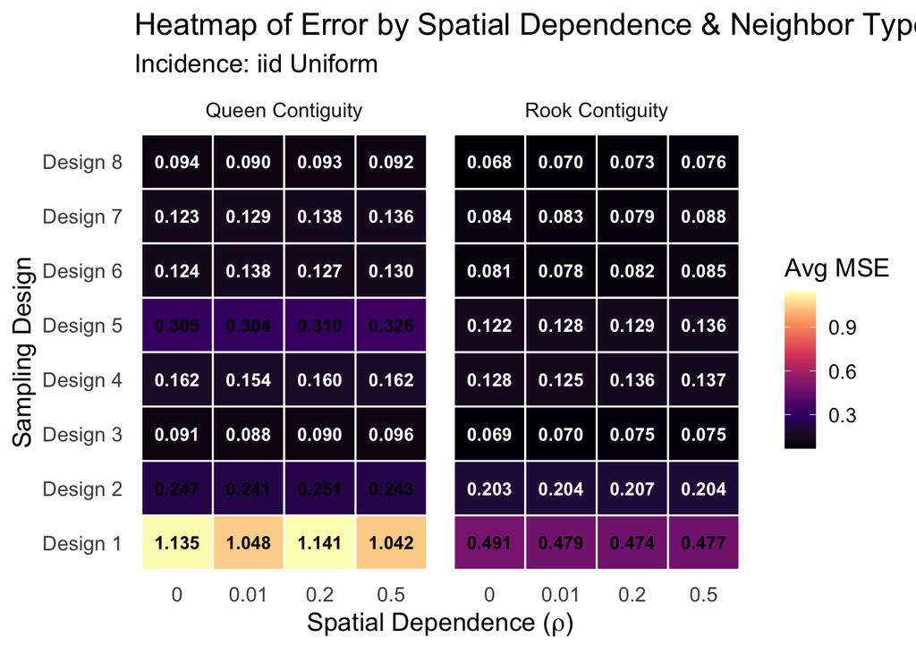

## 16.7 Design Rank Frequency

MLE: Design rank frequency (%) for iid Uniform incidence (tau = 1.0, rook and queen pooled). Each cell = % of scenarios where design achieved that rank.

| Design | Rank_5 | Rank_6 | Rank_8 | Rank_7 | Rank_1 | Rank_2 | Rank_3 | Rank_4 |
| --- | --- | --- | --- | --- | --- | --- | --- | --- |
| Design 8 | 1.6 | 0.0 | 0.0 | 0.0 | 32.8 | 26.6 | 17.2 | 21.9 |
| Design 3 | 3.1 | 0.0 | 0.0 | 0.0 | 31.2 | 31.2 | 15.6 | 18.8 |
| Design 7 | 18.8 | 0.0 | 0.0 | 0.0 | 17.2 | 18.8 | 20.3 | 25.0 |
| Design 6 | 15.6 | 0.0 | 0.0 | 0.0 | 15.6 | 18.8 | 23.4 | 26.6 |
| Design 4 | 17.2 | 25.0 | 12.5 | 12.5 | 3.1 | 3.1 | 20.3 | 6.2 |
| Design 1 | 10.9 | 14.1 | 75.0 | 0.0 | 0.0 | 0.0 | 0.0 | 0.0 |
| Design 2 | 0.0 | 26.6 | 12.5 | 60.9 | 0.0 | 0.0 | 0.0 | 0.0 |
| Design 5 | 32.8 | 34.4 | 0.0 | 26.6 | 0.0 | 1.6 | 3.1 | 1.6 |

# 17 Conclusions and Future Work

The simulation study evaluated 8 treatment assignment designs across 12,800 scenarios; the findings below use the 2,560 $\tau = 1.0$ scenarios with rook and queen pooled unless stated.

## 17.1 Limitations and Planned Extensions

- **Oracle MLE:** The MLE model uses the true spillover covariate. A non-oracle sensitivity analysis ($Y \sim Z + X$) was run on the same outcomes (`results/sim_data/sim_results_MLEnonoracle_tau_sweep_combined_20260924_025509.rds`) but is not reported here.
- **Tau sensitivity:** $\tau$ was swept across $\{0.8, 1.0, 1.5, 2.0, 3.0\}$ in the completed tau-sweep run (12,800 scenarios). See Section 18 for power curves and rank-stability results. Primary results use $\tau = 1.0$.
- **Equal populations:** Poisson mode uses $P_i = 100{,}000$ for all clusters.
- **Grid sensitivity:** Results use $G = 10$ ($N = 100$) only.

# 18 Tau Sensitivity Analysis

The completed tau-sweep simulation (12,800 scenarios) swept $\tau \in \{0.8, 1.0, 1.5, 2.0, 3.0\}$. This section asks: do the design rankings established at $\tau = 1.0$ hold across other effect sizes, and when do designs achieve adequate statistical power?

## 18.1 MSE Across Tau Values

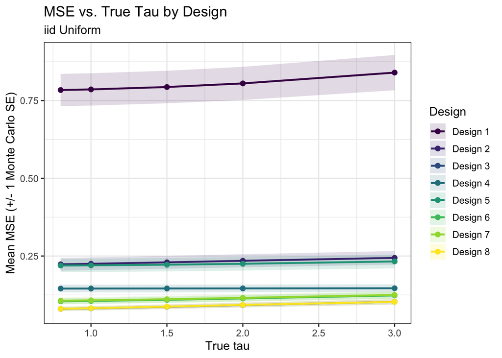

MSE by design across tau values (iid Uniform incidence, rook and queen pooled). Bands show +/- 1 surface-level Monte Carlo SE. Checkerboard is worst at every tau.

## 18.2 Power Curves

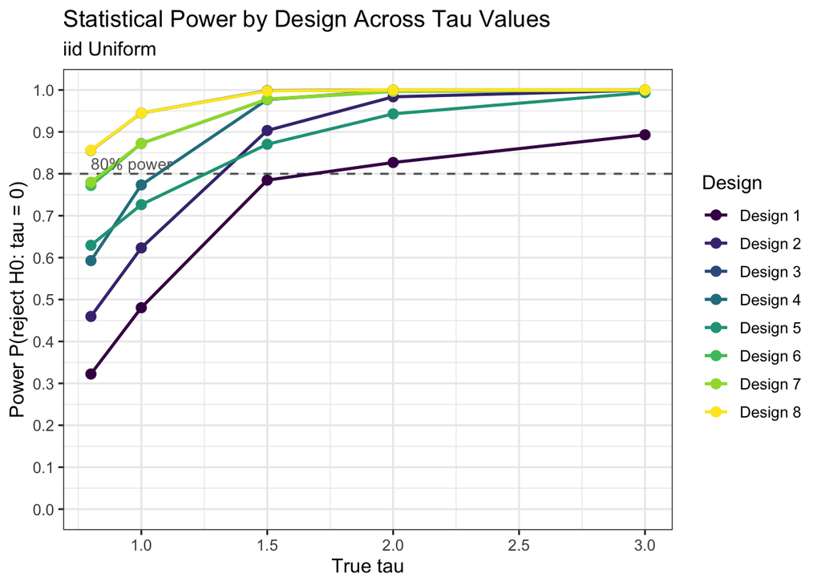

Statistical power P(reject H0: tau=0) by design across tau values (iid Uniform, rook and queen pooled). 80% power reference shown. Efficient designs reach 80% power at smaller effect sizes.

## 18.3 Coverage Across Tau Values

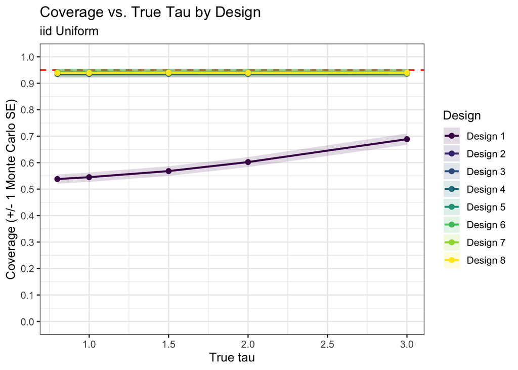

MLE coverage by design across tau values (iid Uniform, rook and queen pooled). Nominal 95% reference shown. Valid designs maintain coverage independent of effect size.

## 18.4 Rank Stability Across Tau Values

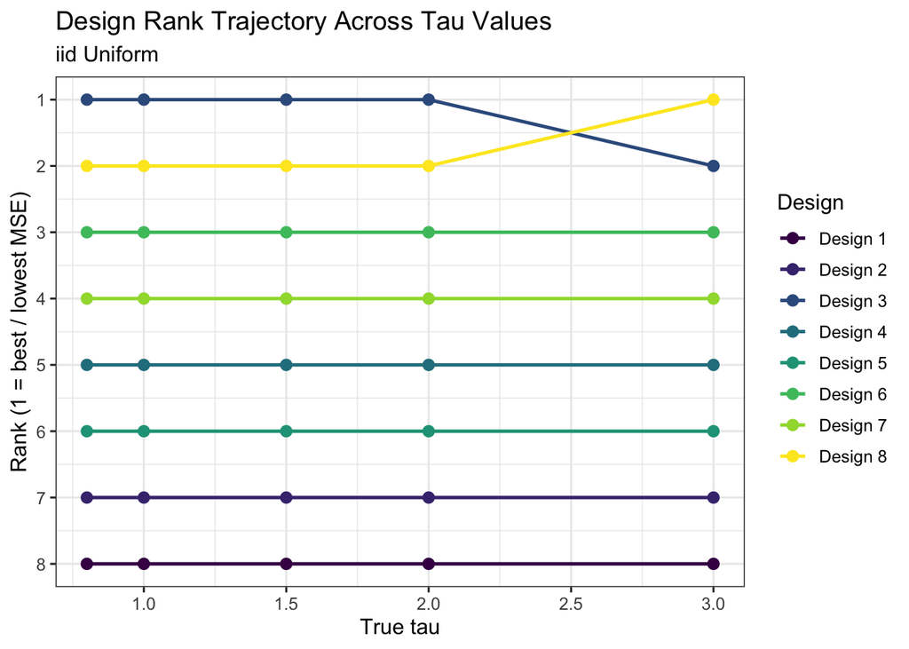

Design rank trajectories across tau values (iid Uniform, rook and queen pooled; rank 1 = best MSE). Stable trajectories show that the top ranking of Saturation Quadrants and Incidence-Guided Saturation Quadrants is not an artifact of the primary effect size. Each tau reuses the same design and noise draws, so the tau levels are not independent confirmations.

## 18.5 Monte Carlo Standard Errors

The `N_Valid_Est` column records the number of valid MLE estimates per scenario. All 2,560 primary-scenario (τ=1.0) rows have `N_Valid_Est = 250` (full convergence), and this holds across all 12,800 tau-sweep scenarios (Fail_Rate = 0.0 everywhere), so reported MSE and coverage differences are not driven by MLE failures. (Checkerboard × rook fits are all flagged as aliased: they converge, but $\tau$ is not identified.)

The Monte Carlo (MC) standard errors shown below are the stored surface-level SEs (`SE_MSE`): for each scenario, the MSE is computed separately on each of the $K = 10$ incidence surfaces, and $\text{SE} = \text{sd}(\text{MSE}_1, \ldots, \text{MSE}_{10}) / \sqrt{10}$. The surface is the primary sampling unit, so the 250 fits are not treated as independent.

Monte Carlo standard errors for MSE, tau = 1.0 slice (2,560 scenarios, rook and queen pooled). MC SE is the surface-level SE (sd of the 10 surface-level MSEs / sqrt(10)), averaged over scenarios. The SEs are small relative to the gaps between most designs, but not relative to the gap between Saturation Quadrants and Incidence-Guided Saturation Quadrants, or between Balanced Quartiles and Balanced Halves. These are per-design SEs, not SEs of paired differences.

| Design | Mean N Valid | Mean MSE | MC SE (MSE) |
| --- | --- | --- | --- |
| Design 3 | 250 | 0.0804 | 0.00706 |
| Design 8 | 250 | 0.0812 | 0.00713 |
| Design 7 | 250 | 0.1071 | 0.00975 |
| Design 6 | 250 | 0.1073 | 0.00983 |
| Design 4 | 250 | 0.1465 | 0.01275 |
| Design 5 | 250 | 0.2237 | 0.02064 |
| Design 2 | 250 | 0.2258 | 0.02124 |
| Design 1 | 250 | 0.7834 | 0.05582 |

# 19 Appendix A: Simulation Pseudocode

Revised structure (2026-09). Every random draw is preceded by `set.seed(digest2int(key))` with the key shown; K = 10 surfaces, J = 25 design draws per surface.

```
BUILD spatial grid -> coords, W_rook, W_queen

FOR EACH incidence config (mode, rho_X) IN {iid; spatial 0.20, 0.50; poisson 0.20, 0.50}:
  FOR k IN 1:K:
    GENERATE surface X_k                         # key "X", mode, rho_X, k
                                                 # (spatial filters use W_queen; poisson P = 100,000)

  FOR EACH nb_type IN {rook, queen}:
    FOR EACH rho IN {0.00, 0.01, 0.20, 0.50}:
      COMPUTE inv_mat = solve(I - rho * W)
      FOR EACH gamma IN {0.50, 0.60, 0.70, 0.80}:
        FOR EACH spill_type IN {control_only, both}:        # one "block"
          GENERATE Epsilon (N x K*J) ~ N(0, 1)       # key "eps", mode, rho_X, nb, rho, gamma, spill_type
                                                     # shared by all 8 designs and all tau

          FOR EACH design d IN 1:8:
            FOR k IN 1:K:
              GENERATE Z_k1..Z_kJ from X_k           # key "Z", mode, rho_X, nb, rho, gamma, spill_type, k, d
                                                     # (Checkerboard: same Z every time)
            FOR EACH tau IN {0.8, 1.0, 1.5, 2.0, 3.0}:
              FOR each fit (k, j):
                Y = inv_mat %*% (tau*Z_kj + Spill(Z_kj) + beta*X_k + eps_kj)
                FIT oracle  Y ~ Z + Spill + X_k      # fit_sar_lag(); flag aliased fits
                FIT non-oracle Y ~ Z + X_k           # same Y
              COMPUTE Bias, SD, MSE, Coverage, Power, Fail_Rate over the 250 fits
              COMPUTE surface-level SEs from the K per-surface metrics
              STORE one results row per estimator
```

# 20 Appendix B: File Locations

RDS result files

| File | Location |
| --- | --- |
| run_info_20260924_025509.rds | results/sim_data/ |
| sim_results_DIM_combined_20260304_195321.rds | results/sim_data/ |
| sim_results_DIM_iid_20260304_195321.rds | results/sim_data/ |
| sim_results_DIM_poisson_20260304_195321.rds | results/sim_data/ |
| sim_results_DIM_spatial_20260304_195321.rds | results/sim_data/ |
| sim_results_MLE_tau_sweep_combined_20260924_025509.rds | results/sim_data/ |
| sim_results_MLE_tau_sweep_iid_20260924_025509.rds | results/sim_data/ |
| sim_results_MLE_tau_sweep_poisson_20260924_025509.rds | results/sim_data/ |
| sim_results_MLE_tau_sweep_spatial_20260924_025509.rds | results/sim_data/ |
| sim_results_MLEnonoracle_tau_sweep_combined_20260924_025509.rds | results/sim_data/ |
| sim_results_MLEnonoracle_tau_sweep_iid_20260924_025509.rds | results/sim_data/ |
| sim_results_MLEnonoracle_tau_sweep_poisson_20260924_025509.rds | results/sim_data/ |
| sim_results_MLEnonoracle_tau_sweep_spatial_20260924_025509.rds | results/sim_data/ |
| surface_results_MLE_tau_sweep_20260924_025509.rds | results/sim_data/ |
| surface_results_MLEnonoracle_tau_sweep_20260924_025509.rds | results/sim_data/ |

All simulation data files are located in: `results/sim_data/`

Code modules: `code/01_spatial_setup.R` through `code/08_design_recommendations.R`

Reports: `code/00_mathematical_specification.Rmd`, `code/07_results_summary.qmd`, `code/09_MLE_design_recommendation_report.qmd`